# Smrti policistov in policistk v Ameriki

# Analiza podatkov

## Čin policista/policistke

Pri analizi podatkov činov policijskega osebja iz ZDA ni bilo mogoče najti hiearhije, poleg tega je v našem naboru podatkov različnih činov 615.

```r
pdeaths %>% distinct(Rank) %>% count()
```

```
## # A tibble: 1 × 1
##       n
##   <int>
## 1   615
```

Kot lahko vidimo iz analize podatkov, je največ umrlega policijskega osebja bilo čina “Patrolman”, nato sledi “Police Officer”, ter nato še “Deputy Sherrif”.

```r
pdeaths %>% group_by(Rank) %>% count(sort = T) %>% head(10)
```

```
## # A tibble: 10 × 2
## # Groups:   Rank [10]
##    Rank                n
##    <chr>           <int>
##  1 Patrolman        3876
##  2 Police Officer   3549
##  3 Deputy Sheriff   3224
##  4 Officer          1746
##  5 Sergeant         1423
##  6 Detective         861
##  7 Trooper           857
##  8 Sheriff           775
##  9 Chief of Police   691
## 10 Constable         589
```

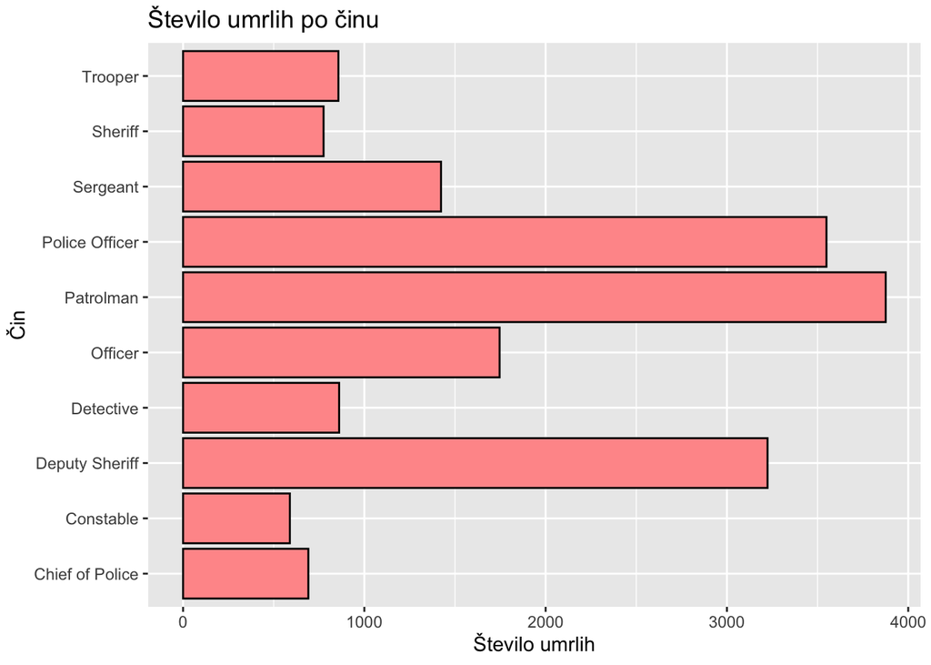

```r
ggplot(pdeaths %>% select(Rank) %>% group_by(Rank) %>% count(sort = T)  %>% head(10)) +
  aes(n, Rank) +
  geom_col() +  ggtitle("Število umrlih po činu") +
  geom_bar(stat="identity", fill="#FF9999", colour="black") +
  labs(y= "Čin", x = "Število umrlih")
```

Če pa pogledamo čine umrlih, kateri se najmanj krat pojavijo, vidimo, da je teh 252.

```r
pdeaths %>% group_by(Rank) %>%  summarise(n = n()) %>% filter(n == min(n)) %>% count()
```

```
## # A tibble: 1 × 1
##       n
##   <int>
## 1   252
```

Če samo pogledamo nekatere izmed teh činov, vidimo, da ima veliko od njih starejša oziroma stara imena, katera danes niso več v uporabi, na primer Wagonman.

```r
pdeaths %>% group_by(Rank) %>%  summarise(n = n()) %>% filter(n == min(n)) %>% map_df(rev)
```

```
## # A tibble: 252 × 2
##    Rank                              n
##    <chr>                         <int>
##  1 Youth Officer                     1
##  2 Youth Development                 1
##  3 Youth Counselor                   1
##  4 Wildlife Technician               1
##  5 Wildlife Manager                  1
##  6 Wildlife Conservation Officer     1
##  7 Watch Officer                     1
##  8 Warrants Officer                  1
##  9 Warden Supervisor                 1
## 10 Wagonman                          1
## # … with 242 more rows
```

## Ime policista/policistke

Glede imen policistiv/policistk, podobne analize podatkov, kot je bila narejena prej pri “Činu”, ni smiselna, saj grupiranje po imenu načeloma ni smiselno, saj se ne gre za isto osebo.

Ker pa imamo v naboru podatkov tudi imena psov (K9), ki so preminuli med policijskim delom, lahko pogledamo, če so imeli psi enaka imena.

Nato odstranimo vsa imena, ki se pojavijo samo enkrat.

```r
pdeaths %>% group_by(Name) %>% count(sort = T) %>% filter(n > 1)
```

```
## # A tibble: 179 × 2
## # Groups:   Name [179]
##    Name       n
##    <chr>  <int>
##  1 Max        6
##  2 Rocky      6
##  3 Duke       5
##  4 King       5
##  5 Major      5
##  6 Roscoe     5
##  7 Bandit     4
##  8 Billy      4
##  9 Ike        4
## 10 Rex        4
## # … with 169 more rows
```

Kot lahko vidimo, so nekater umrli policisti/policistke in psi imeli enaka imena. Seveda je velika večina podvojenih imen, od psov.

## Vzrok smrti

Pri analizi vzrokov smrti policijskega osebja, najprej pogledamo katerih vzrokov za smrt je bilo največ.

```r
pdeaths %>% group_by(Cause_of_Death) %>% count(sort = T) %>% head(10)
```

```
## # A tibble: 10 × 2
## # Groups:   Cause_of_Death [10]
##    Cause_of_Death            n
##    <chr>                 <int>
##  1 Gunfire               13105
##  2 Automobile crash       2567
##  3 Heart attack           1216
##  4 Motorcycle crash       1167
##  5 Vehicular assault      1000
##  6 Struck by vehicle       986
##  7 COVID19                 771
##  8 Assault                 712
##  9 Gunfire (Inadvertent)   693
## 10 Vehicle pursuit         692
```

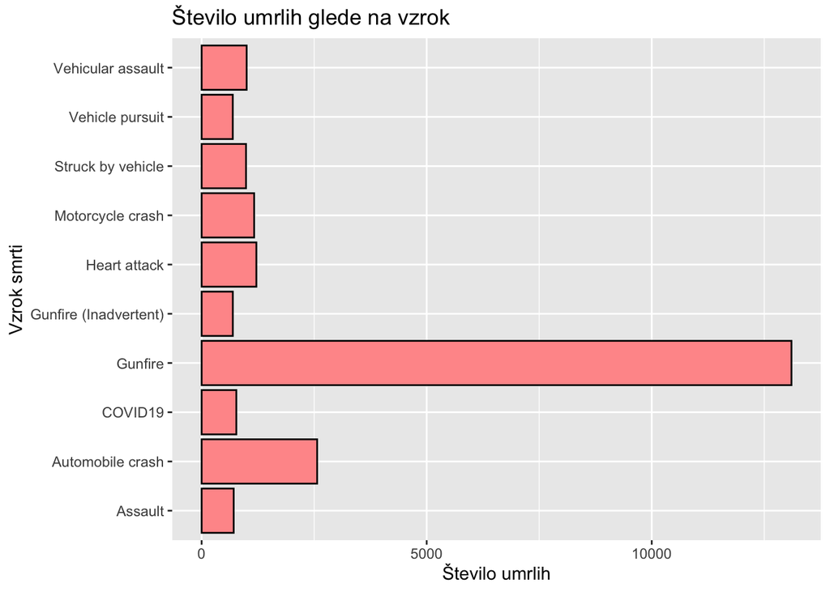

```r
ggplot(pdeaths %>% select(Cause_of_Death) %>% group_by(Cause_of_Death) %>% count(sort = T)  %>% head(10)) +
  aes(n, Cause_of_Death) +
  geom_col() + ggtitle("Število umrlih glede na vzrok ") +
  geom_bar(stat="identity", fill="#FF9999", colour="black") +
  labs(y= "Vzrok smrti", x = "Število umrlih")
```

Spodnji rezultati nam prikazujej najmanj pogoste vzroke za smrt. Najmanj pogost razlog je zastoj dihanja. Nato sledi neznan razlog, nato pa zastrupitev.

```r
pdeaths %>% group_by(Cause_of_Death) %>% count(sort = T) %>% map_df(rev)
```

```
## # A tibble: 37 × 2
##    Cause_of_Death               n
##    <chr>                    <int>
##  1 Asphyxiation                 3
##  2 Unidentified                 4
##  3 Poisoned                     6
##  4 Bicycle accident            14
##  5 Boating accident            16
##  6 Hypothermia                 19
##  7 Structure collapse          23
##  8 Train accident              27
##  9 Weather/Natural disaster    37
## 10 Training accident           38
## # … with 27 more rows
```

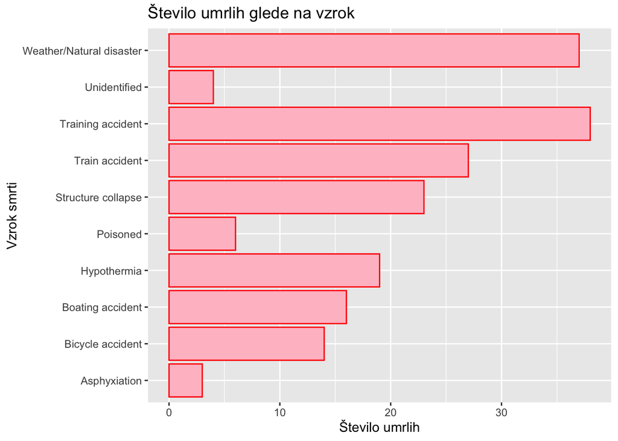

```r
ggplot(pdeaths %>% group_by(Cause_of_Death) %>% count(sort = T) %>% map_df(rev) %>% head(10)) +
  aes(n, Cause_of_Death) +
  geom_col() + ggtitle("Število umrlih glede na vzrok ") +
  geom_bar(stat="identity", fill="pink", colour="red") +
  labs(y= "Vzrok smrti", x = "Število umrlih")
```

## Datum

Glede datuma nas predvsem zanima katera obdobja je umrlo največ policijskega osebja in katera obdobja jih je umrlo najmanj.

Najprej pogledamo za koliko dni, mesecev in let imamo sploh podatke o smrtih med policijskim osebjem. Ta številka nam pove, da je od 1791 pa do 2022, prišlo do smrtne žrtve med policijskim osebjem v 19218 dnevih.

```r
pdeaths %>% distinct(Date)  %>% count()
```

```
## # A tibble: 1 × 1
##       n
##   <int>
## 1 19218
```

Nato pogledamo na kateri dan je prišlo do največ smrtnih žrtev.

```r
pdeaths %>% group_by(Date) %>% count(sort = T) %>% head(10)
```

```
## # A tibble: 10 × 2
## # Groups:   Date [10]
##    Date                            n
##    <chr>                       <int>
##  1 Tuesday, September 11, 2001    73
##  2 Wednesday, April 27, 1870      11
##  3 Friday, November 10, 1837      10
##  4 Saturday, November 24, 1917    10
##  5 Saturday, January 2, 1932       9
##  6 Wednesday, April 19, 1995       9
##  7 Wednesday, August 25, 2021      9
##  8 Friday, August 20, 2021         8
##  9 Monday, September 13, 2021      8
## 10 Sunday, February 20, 1927       8
```

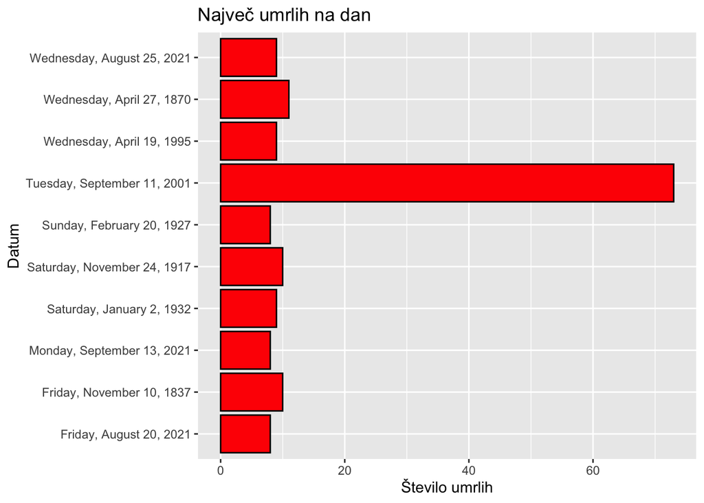

```r
ggplot(pdeaths %>% group_by(Date) %>% count(sort = T) %>% head(10)) +
  aes(n, Date) +
  geom_col() + ggtitle("Največ umrlih na dan ") +
  geom_bar(stat="identity", fill="red", colour="black") +
  labs(y= "Datum", x = "Število umrlih")
```

Če analiziramo podatke za število smrtnih žrtev po letih, vidimo, da je bilo največ smrtnih žrtev leta 2021. Takoj za letom 2021, je po številu smrtnih žrtev med policijskim osebjem, leto 2020. Pred tem, pa sta leti 1930 in 1927.

```r
pdeaths %>% group_by(Year) %>% count(sort = T) %>% head(5)
```

```
## # A tibble: 5 × 2
## # Groups:   Year [5]
##    Year     n
##   <dbl> <int>
## 1  2021   643
## 2  2020   436
## 3  1930   347
## 4  1927   335
## 5  1932   327
```

Če pogledamo leta, na katera je umrlo najmanj policijskega osebja, vidimo, da se je to zgodilo 17krat. Lahko sklepamo, da so ti podatki napačni, najverjetneje pa zato, ker so takrat slabše beležili podatke.

```r
pdeaths %>% group_by(Year) %>% select(Year) %>% summarise(n = n()) %>% filter(n==1) %>% count()
```

```
## # A tibble: 1 × 1
##       n
##   <int>
## 1    17
```

## Leto

```r
ggplot(leta, aes(x=Year, y=n, group=1)) +
  geom_line(color="red", size = 1)+
  geom_point() +
  ggtitle("Smrti po letih") +
  labs(x="Leta",y="Število smrti")
```

[output not shown]

[output not shown]

## Dan

Če pogledamo dneve in število smrtnih žrtev na dan v tednu, vidimo sledeče:

```r
pdeaths %>% group_by(Day) %>% summarise(n = n()) %>% arrange(desc(n))
```

```
## # A tibble: 7 × 2
##   Day           n
##   <chr>     <int>
## 1 Saturday   4070
## 2 Friday     3847
## 3 Sunday     3832
## 4 Thursday   3725
## 5 Tuesday    3613
## 6 Monday     3606
## 7 Wednesday  3576
```

- največ policijskega osebja je umrlo v Soboto
- najmanj policijskega osebja je umrlo v Sredo

## Oddelki in zvezne države

Ko analiziramo podatke za smrti policijskega osebja, natančneje, ko se osredotočamo na Oddelke, kjer je do smrtnih žrtev prišlo, vidimo, da je Oddelek z največ smrtmi “New York City Police Department”. Za njim sledi “Chicago Police Department”, nato pa “Puerto Rico Department”.

```r
pdeaths %>% group_by(Department) %>% count(sort = T)  %>% head(7)
```

```
## # A tibble: 7 × 2
## # Groups:   Department [7]
##   Department                                                                   n
##   <chr>                                                                    <int>
## 1 New York City Police Department, NY                                        964
## 2 Chicago Police Department, IL                                              523
## 3 Puerto Rico Police Department, PR                                          358
## 4 Philadelphia Police Department, PA                                         320
## 5 United States Department of Justice - United States Marshals Service, US   306
## 6 Detroit Police Department, MI                                              243
## 7 California Highway Patrol, CA                                              231
```

Nato pa pogledamo v kateri zvezni državi je umrlo največ policistov in sklepamo, da bi to morali po vrsti biti najprej New York, Chicago in nato Puero Rico.

```r
pdeaths %>% group_by(State) %>% count(sort = T)  %>% head(7)
```

```
## # A tibble: 7 × 2
## # Groups:   State [7]
##   State             n
##   <chr>         <int>
## 1 Texas          2229
## 2 United States  1970
## 3 New York       1880
## 4 California     1781
## 5 Illinois       1174
## 6 Pennsylvania   1105
## 7 Florida         976
```

Vidimo, da to ne drži, saj je prva izmed zveznih držav Texas. Razlog zakaj ni največ smrtnih žrtev v New Yorku, čeprav je bilo tako pričakovati, je enostaven. Policijski oddelki v New Yorku, Chicagu in Puerto Ricu pokrivajo zelo velika območja, poleg tega pa so ta območja tudi zelo gosto poseljena. Zaradi tega lahko sklepamo na večji odstotek kriminala (zaradi visoke gostote prebivalstva) in posledični tudi na več smrti med policijskim osebjem.

Če nato pogledamo oddelke, kjer je prišlo do 1 smrtne žrtve (nemoremo pogledati oddelkov, ki imajo najmanj smrtnih žrtev, se pravi nobene, ker teh ni v naboru podatkov, tako da najmanj smrtnih žrtev je v našem primeru 1 smrtna žrtev), vidimo, da je teh zelo veliko, natančneje 4145.

```r
pdeaths %>% group_by(Department) %>% select(Department) %>% summarise(n = n()) %>% filter(n==1) %>% count()
```

```
## # A tibble: 1 × 1
##       n
##   <int>
## 1  4145
```

Če nato te oddelke z 1 smrtno žrtvijo primerjamo z zveznimi državami z najmanj žrtvami, vidimo sledeče:

```r
pdeaths %>% group_by(State) %>% count(sort = T) %>% map_df(rev) #drzava min
```

```
## # A tibble: 58 × 2
##    State                        n
##    <chr>                    <int>
##  1 Panama                       3
##  2 Northern Mariana Islands     3
##  3 American Samoa               3
##  4 U.S. Virgin Islands         14
##  5 Guam                        14
##  6 Vermont                     30
##  7 Delaware                    48
##  8 New Hampshire               51
##  9 Alaska                      51
## 10 Rhode Island                53
## # … with 48 more rows
```

Najmanjše število policijskih smrtnih žrtev v zvezni državi je 3. To število smrtnih žrtev imajo 3 zvezne države in sicer: Panama, Northern Mariana Islands in American Samoa.

```r
pdeaths %>% group_by(State) %>% select(State) %>% summarise(n = n()) %>% filter(n == min(n)) -> minDrzava
minDrzava[1,2]
```

```
## # A tibble: 1 × 1
##       n
##   <int>
## 1     3
```

```r
pdeaths %>% group_by(State) %>% select(State) %>% summarise(n = n()) %>% filter(n == min(n))
```

```
## # A tibble: 3 × 2
##   State                        n
##   <chr>                    <int>
## 1 American Samoa               3
## 2 Northern Mariana Islands     3
## 3 Panama                       3
```

```r
pdeaths %>% group_by(State) %>% select(State) %>% summarise(n = n()) %>% filter(n == min(n)) %>% count()
```

```
## # A tibble: 1 × 1
##       n
##   <int>
## 1     3
```

## Pasje enote

V našem naboru podatkov imajo pasje enote (K9_Unit) v zadnjem stolpcu edine vrednost 1. Poleg tega imajo vse preminule pasje enote tudi svoj Čin (K9).

Najprej pogledamo koliko različnih vzrokov za smrt je v našem naboru podatkov za pse.

```r
pdeaths %>% filter(K9_Unit == 1) -> dogs
dogs %>% group_by(Cause_of_Death) %>% summarise(n = n()) %>% arrange(n) %>% map_df(rev) %>% count()
```

```
## # A tibble: 1 × 1
##       n
##   <int>
## 1    24
```

Nato pogledamo kateri so najpogostejši razlogi za smrt pasjih enot, vidimo, da je najpogostejši razlog smrt zaradi strelnega orožja.

```r
dogs %>% group_by(Cause_of_Death) %>% summarise(n = n()) %>% arrange(n) %>% map_df(rev) %>% head(6)
```

```
## # A tibble: 6 × 2
##   Cause_of_Death            n
##   <chr>                 <int>
## 1 Gunfire                 140
## 2 Heatstroke               81
## 3 Struck by vehicle        58
## 4 Automobile crash         27
## 5 Gunfire (Inadvertent)    26
## 6 Fall                     25
```

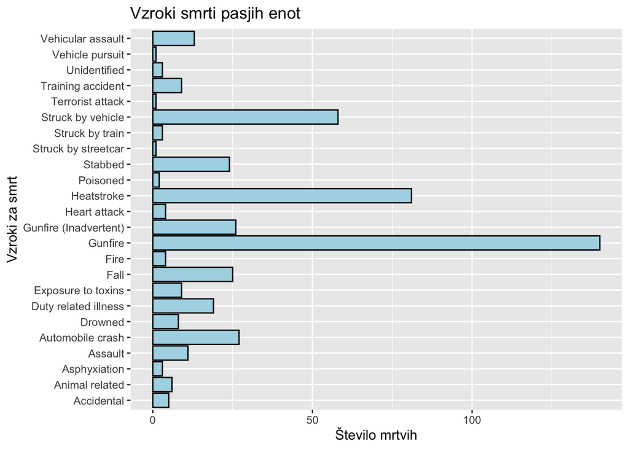

```r
ggplot(dogs %>% group_by(Cause_of_Death) %>% summarise(n = n()) %>% arrange(n) %>% map_df(rev)) +
  aes(n, Cause_of_Death ) +
  geom_col() + ggtitle("Vzroki smrti pasjih enot") +
  geom_bar(stat = "identity", fill="lightblue", colour="black") +
  labs(y="Vzroki za smrt", x="Število mrtvih")
```

Tu ni presenetljivo, da je največ psov umrlo zaradi ustrelitve. Zelo je zanimiv podatek, da je drugi najpogostejši razlog za smrt policijskega psa (ki ni naravna smrt), vročinska kap. To je zanimivo, ker vročinska kap ni smrt, povzročena s strani nekoga drugega, usaj ne namerno, kot je na primer smrt zaradi strelnega orožja.

# Zaključek

Zaključimo lahko, da je za največ smrtnih žrtev med policijskim osebjem v ZDA krivo strelno orožje. To dejstvo ni presenetljivo, saj je v sami ustavi Združenih držav Amerike zapisano, da ima vsak polnoleten američan pravico do orožja. Prav tako ni presenetljivo, da je strelno orožje krivo tudi za daleč največ smrti med pasjimi enotami v policiji v ZDA. Zanimivo pa je, da je drugi najpogostejši razlog za smrt psa v policiji, kriv vročinski udar.

# Reference

https://en.wikipedia.org/wiki/Exploratory_data_analysis

https://www.kaggle.com/datasets/mayureshkoli/police-deaths-in-usa-from-1791-to-2022

https://public.tableau.com/app/profile/mayuresh.koli/viz/USALawEnforcementLineofDutyDeaths/main_dashboard